# Lab 4. Comma

2023-08-07

## Comma police

One of the most widespread data storage format is the *comma separated value* (csv) format. The csv are tabular data: they are made of rows and columns. For the csv files to be good csv files, every rows must have the same number of columns; and conversely every column must have the same number of rows (yes, just as a good dataframe). In general, though, there’s nothing more than that: rows can be variable or observations, depending on who wrote the file. The name *csv* is given by the fact that each *value* in a row is separated by a comma. And rows of value are separated by a break line.

Comma separated value files are *plain text* files: that means that you can open them with a simple text editor and see (and eventually, but don’t do it!, edit) what’s inside.

In this lab we have one example here named “addresses.csv”.

**Question**: what does it happen if you pick (in the Jupyter Lab viewer) a different delimiter?

Indeed, csv files are a particular example of a wider class of files, where values are separated by *some* delimiter. Common ones are tab delimited files, often shortened to *.tsv*.

## Before we start

```r
library(tidyverse)
library(singer)
library(skimr)
```

To read in a csv file, there’s a dedicated function: `read_csv()`. Its output is a dataframe. Let’s see, and **do read the red messages**.

**NOTICE** we are using read_csv, not read.csv, that is underscore (“_”) not dot (“.”).

```r
addresses <- read_csv(file = "../data/addresses.csv")
addresses
```

| John | Doe | 120 jefferson st. | Riverside | NJ | 8075 |
| --- | --- | --- | --- | --- | --- |
| Jack | McGinnis | 220 hobo Av. | Phila | PA | 9119 |
| John "Da Man" | Repici | 120 Jefferson St. | Riverside | NJ | 8075 |
| Stephen | Tyler | 7452 Terrace "At the Plaza" road | SomeTown | SD | 91234 |
| NA | Blankman | NA | SomeTown | SD | 298 |
| Joan "the bone", Anne | Jet | 9th, at Terrace plc | Desert City | CO | 123 |

Well, it looks quite the same thing we have seen opening the file with Jupyter Lab. So, what about that first row? It does not really look it’s the name of variable, the *header*, rather just on row in the dataframe. We can tell `read_csv()` that the first row is just like the other setting the argument `col_names` to false.

```r
addresses <- "../data/addresses.csv" %>%
  read_csv(col_names = FALSE)
addresses
```

| X1 | X2 | X3 | X4 | X5 | X6 |
| --- | --- | --- | --- | --- | --- |
| John | Doe | 120 jefferson st. | Riverside | NJ | 8075 |
| Jack | McGinnis | 220 hobo Av. | Phila | PA | 9119 |
| John "Da Man" | Repici | 120 Jefferson St. | Riverside | NJ | 8075 |
| Stephen | Tyler | 7452 Terrace "At the Plaza" road | SomeTown | SD | 91234 |
| NA | Blankman | NA | SomeTown | SD | 298 |
| Joan "the bone", Anne | Jet | 9th, at Terrace plc | Desert City | CO | 123 |

That’s better: all the rows of data are in the dataframe. But the name of the variable are really not informative.

Sometimes you can read the names from a *data dictionary* (a text file where the authors present the data, the way it is collected, the meaning of each variable). Sometimes you need to “invent” them for yourself.

```r
names_variables <- c(
  "first_name", "family_name", "street_address", "town",
  "state", "zip_code"
)
addresses <- "../data/addresses.csv" %>%
  read_csv(col_names = names_variables)
addresses
```

| first_name | family_name | street_address | town | state | zip_code |
| --- | --- | --- | --- | --- | --- |
| John | Doe | 120 jefferson st. | Riverside | NJ | 8075 |
| Jack | McGinnis | 220 hobo Av. | Phila | PA | 9119 |
| John "Da Man" | Repici | 120 Jefferson St. | Riverside | NJ | 8075 |
| Stephen | Tyler | 7452 Terrace "At the Plaza" road | SomeTown | SD | 91234 |
| NA | Blankman | NA | SomeTown | SD | 298 |
| Joan "the bone", Anne | Jet | 9th, at Terrace plc | Desert City | CO | 123 |

Try again giving different names.

```r
addresses %>% rename(
  ST = state,
  ZIP = zip_code
)
```

| first_name | family_name | street_address | town | ST | ZIP |
| --- | --- | --- | --- | --- | --- |
| John | Doe | 120 jefferson st. | Riverside | NJ | 8075 |
| Jack | McGinnis | 220 hobo Av. | Phila | PA | 9119 |
| John "Da Man" | Repici | 120 Jefferson St. | Riverside | NJ | 8075 |
| Stephen | Tyler | 7452 Terrace "At the Plaza" road | SomeTown | SD | 91234 |
| NA | Blankman | NA | SomeTown | SD | 298 |
| Joan "the bone", Anne | Jet | 9th, at Terrace plc | Desert City | CO | 123 |

### Col types

Not all columns are the same stuff. Just by looking at the code, what do you expect the type of the data for each column to be?

> Expect all character except zip code

Now compare your previous answer with the type of the data in the columns that you can discover using, for example, `glimpse()`.

```r
addresses %>% glimpse()
```

```
## Rows: 6
## Columns: 6
## $ first_name     <chr> "John", "Jack", "John \"Da Man\"", "Stephen", NA, "Joan…
## $ family_name    <chr> "Doe", "McGinnis", "Repici", "Tyler", "Blankman", "Jet"
## $ street_address <chr> "120 jefferson st.", "220 hobo Av.", "120 Jefferson St.…
## $ town           <chr> "Riverside", "Phila", "Riverside", "SomeTown", "SomeTow…
## $ state          <chr> "NJ", "PA", "NJ", "SD", "SD", "CO"
## $ zip_code       <dbl> 8075, 9119, 8075, 91234, 298, 123
```

Is it the same?

Well, there was one column which may have confused you: the zip code. Those looks like numbers, integers to be specific.

Yet some of them have zeros in front of the other digits. For an integer, that should not be a big problem, we can understand how to read the following number:

> 0019

> “0019”

We can have a preview of what kind of object `read_csv()` will produce by using `guess_parser()`. Consider the following examples.

```r
"0019" %>% guess_parser()
```

```
## [1] "character"
```

```r
"19" %>% guess_parser()
```

```
## [1] "double"
```

```r
"1.9" %>% guess_parser()
```

```
## [1] "double"
```

```r
"1,9" %>% guess_parser()
```

```
## [1] "number"
```

```r
"1900-03-01" %>% guess_parser()
```

```
## [1] "date"
```

```r
"1900-33-33" %>% guess_parser()
```

```
## [1] "date"
```

`readr` tries to guess the type of the values it reads in a file, but he does not ALWAYS get it right. Moreover, it does not guess after having read *all* the rows (that would be inefficient). It reads only a certain number of them, and then guesses and reads the other rows hoping that they are of the same type.

To be rigorous: it guesses the *schema* (do you remember from the first lecture?) and then uses it to read efficiently the csv. `read_csv()` can read stuff from a file on your hard drive or from the web. It can even read compressed (zipped) files without any trouble (if they are in good shape). In general, if something is not *surely* of some other kind, it gets parsed as character.

```r
url_enterprise_survey <- "https://www.stats.govt.nz/assets/Uploads/Annual-enterprise-survey/Annual-enterprise-survey-2017-financial-year-provisional/Download-data/annual-enterprise-survey-2017-financial-year-provisional-csv.csv"

enterprise_survey <- read_csv(url_enterprise_survey)
enterprise_survey %>% sample_n(5)
```

| Year | Industry_aggregation_NZSIOC | Industry_code_NZSIOC | Industry_name_NZSIOC | Units | Variable_code | Variable_name | Variable_category | Value | Industry_code_ANZSIC06 |
| --- | --- | --- | --- | --- | --- | --- | --- | --- | --- |
| 2015 | Level 4 | LL122 | Non-Residential Property Operation | Dollars (millions) | H14 | Salaries and wages to self employed commission agents | Financial performance | 0 | ANZSIC06 class L671200 |
| 2017 | Level 3 | OO21 | Public order, safety and regulatory services | Percentage | H41 | Liabilities structure | Financial ratios | 33 | ANZSIC06 groups O771 and O772 (excluding class O7711) |
| 2015 | Level 3 | EE13 | Construction Services | Dollars (millions) | H27 | Additions to fixed assets | Financial position | 1100 | ANZSIC06 groups E321, E322, E323, E324, and E329 |
| 2014 | Level 4 | PP111 | Preschool Education | Dollars (millions) | H21 | Opening stocks | Financial performance | C | ANZSIC06 group P801 |
| 2017 | Level 4 | MN113 | Advertising, Market Research and Management Services | Dollars (millions) | H06 | Government funding, grants and subsidies | Financial performance | 123 | ANZSIC06 groups M694, M695, and M696 |

### Your turn

Read something from the stats nz [website](https://www.stats.govt.nz/large-datasets/csv-files-for-download).

```r
url_migration <- "https://www.stats.govt.nz/assets/Uploads/International-migration/International-migration-March-2021/Download-data/international-migration-March-2021-citizenship-by-visa-by-country-of-last-permanent-residence.csv"
migration <- read_csv(url_migration)
migration %>% glimpse()
```

```
## Rows: 401,772
## Columns: 10
## $ year_month           <chr> "2020-02", "2020-09", "2020-07", "2020-07", "2020…
## $ month_of_release     <chr> "2021-03", "2021-03", "2021-03", "2021-03", "2021…
## $ passenger_type       <chr> "Long-term migrant", "Long-term migrant", "Long-t…
## $ direction            <chr> "Arrivals", "Arrivals", "Arrivals", "Arrivals", "…
## $ citizenship          <chr> "non-NZ", "non-NZ", "non-NZ", "non-NZ", "NZ", "NZ…
## $ visa                 <chr> "Resident", "Resident", "Visitor", "NZ and Austra…
## $ country_of_residence <chr> "Andorra", "Andorra", "Andorra", "Andorra", "Ando…
## $ estimate             <dbl> 1, 1, 1, 1, 1, 3, 1, 0, 0, 16, 6, 23, 19, 4, 2, 1…
## $ standard_error       <dbl> 0, 0, 0, 0, 0, 0, 0, 0, 0, 0, 0, 0, 0, 0, 0, 0, 1…
## $ status               <chr> "Provisional", "Provisional", "Provisional", "Pro…
```

```r
migration %>%
  filter(
    direction == "Arrivals", year_month == "2020-02",
    passenger_type == "Long-term migrant"
  ) %>%
  group_by(country_of_residence) %>%
  summarise(Total_Arrivals = sum(estimate)) %>%
  arrange(desc(Total_Arrivals)) %>%
  head(10)
```

| country_of_residence | Total_Arrivals |
| --- | --- |
| TOTAL | 606544 |
| Asia | 247183 |
| Oceania and Antarctica | 163662 |
| India | 113914 |
| Australia | 84117 |
| Europe | 75507 |
| The Americas | 45249 |
| Africa and the Middle East | 44992 |
| United Kingdom | 35794 |
| Not Stated | 29949 |

## When things go bad

Yet, this can go wrong sometimes. In the two following examples we will encouter some issue and work out if we can safely ignore them or we need to correct them. Remember, the decision depends on what data you are working on and for what purpose. Somebody else working on our examples may come to a different conclusion.

### Example 1

Let’s try with a big and wild csv from [here](https://www.stats.govt.nz/large-datasets/csv-files-for-download/):

`Overseas trade index: March 2020 quarter (provisional) – CSV.`

Refer to the website to discover the meaning of the variables!

```r
test_url <- "https://www.stats.govt.nz/assets/Uploads/overseas-merchandise-trade-datasets/omt-datasets-june-2021/Jun-2021-Imports-HS10-by-Country.csv"
test <- test_url %>% read_csv()
```

```
## ──────────────────────────────────────────────────────── Delimiter: "," chr
## (4): Harmonised System Description, Unit Qty, Country, Status dbl (2): Month,
## Harmonised System Code num (3): Imports ($NZD vfd), Imports ($NZD cif), Imports
## Qty lgl (1): ...10
```

```r
spec(test)
Overseas_ti_url <- "https://www.stats.govt.nz/assets/Uploads/Overseas-trade-indexes-prices-and-volumes/Overseas-trade-indexes-prices-and-volumes-March-2020-quarter-provisional/Download-data/overseas-trade-indexes-march-2020-provisional.csv"

Overseas_ti <- Overseas_ti_url %>% read_csv()
spec(Overseas_ti)
```

We actually are no longer getting parsing warnings as the dataset has been fixed by STATSNZ. We can specify column parsing and try to understand what’s going on. We are suggested us to use `problems()` for more details. Let’s do it.

```r
Overseas_ti_alt <- Overseas_ti_url %>% read_csv(col_types = cols(
  Series_reference = col_character(),
  Period = col_double(),
  Data_value = col_double(),
  STATUS = col_character(),
  UNITS = col_character(),
  MAGNTUDE = col_double(),
  Subject = col_character(),
  Group = col_character(),
  Series_title_1 = col_character(),
  Series_title_2 = col_character(),
  Series_title_3 = col_character(),
  Series_title_4 = col_integer(),
  Series_title_5 = col_character()
))
```

```
## Warning: One or more parsing issues, call `problems()` on your data frame for details,
## e.g.:
##   dat <- vroom(...)
##   problems(dat)
```

```r
Overseas_ti_alt %>%
  problems() %>%
  head(10)
```

| row | col | expected | actual | file |
| --- | --- | --- | --- | --- |
| 30863 | 12 | an integer | Seasonally adjusted |  |
| 30864 | 12 | an integer | Seasonally adjusted |  |
| 30865 | 12 | an integer | Seasonally adjusted |  |
| 30866 | 12 | an integer | Seasonally adjusted |  |
| 30867 | 12 | an integer | Seasonally adjusted |  |
| 30868 | 12 | an integer | Seasonally adjusted |  |
| 30869 | 12 | an integer | Seasonally adjusted |  |
| 30870 | 12 | an integer | Seasonally adjusted |  |
| 30871 | 12 | an integer | Seasonally adjusted |  |
| 30872 | 12 | an integer | Seasonally adjusted |  |

```r
Overseas_ti %>% slice(30860:30870)
```

| Series_reference | Period | Data_value | STATUS | UNITS | MAGNTUDE | Subject | Group | Series_title_1 | Series_title_2 | Series_title_3 | Series_title_4 | Series_title_5 |
| --- | --- | --- | --- | --- | --- | --- | --- | --- | --- | --- | --- | --- |
| OTVQ.SEO3E98 | 2019.12 | 1.503103e+07 | FINAL | Dollars | 3 | Overseas Trade Indexes - Volumes and Values - OTV | Export volume indexes and values - analytical - other bases and years | Value: $(thousand) vfd or fob | TOTAL EXPORTS | June 1999 Quarter Base (=1000) | NA | NA |
| OTVQ.SEO3E98 | 2020.03 | 1.480646e+07 | PROVISIONAL | Dollars | 3 | Overseas Trade Indexes - Volumes and Values - OTV | Export volume indexes and values - analytical - other bases and years | Value: $(thousand) vfd or fob | TOTAL EXPORTS | June 1999 Quarter Base (=1000) | NA | NA |
| OTVQ.SES2AE1S | 1990.06 | 5.568896e+02 | REVISED | Index | 0 | Overseas Trade Indexes - Volumes and Values - OTV | Export volume indexes and values - analytical - seasonally adjusted and trend | Volume | TOTAL MEAT | June 2002 Quarter Base (=1000) | Seasonally adjusted | NA |
| OTVQ.SES2AE1S | 1990.09 | 6.342956e+02 | REVISED | Index | 0 | Overseas Trade Indexes - Volumes and Values - OTV | Export volume indexes and values - analytical - seasonally adjusted and trend | Volume | TOTAL MEAT | June 2002 Quarter Base (=1000) | Seasonally adjusted | NA |
| OTVQ.SES2AE1S | 1990.12 | 7.795556e+02 | REVISED | Index | 0 | Overseas Trade Indexes - Volumes and Values - OTV | Export volume indexes and values - analytical - seasonally adjusted and trend | Volume | TOTAL MEAT | June 2002 Quarter Base (=1000) | Seasonally adjusted | NA |
| OTVQ.SES2AE1S | 1991.03 | 6.150987e+02 | REVISED | Index | 0 | Overseas Trade Indexes - Volumes and Values - OTV | Export volume indexes and values - analytical - seasonally adjusted and trend | Volume | TOTAL MEAT | June 2002 Quarter Base (=1000) | Seasonally adjusted | NA |
| OTVQ.SES2AE1S | 1991.06 | 6.331878e+02 | REVISED | Index | 0 | Overseas Trade Indexes - Volumes and Values - OTV | Export volume indexes and values - analytical - seasonally adjusted and trend | Volume | TOTAL MEAT | June 2002 Quarter Base (=1000) | Seasonally adjusted | NA |
| OTVQ.SES2AE1S | 1991.09 | 7.189057e+02 | REVISED | Index | 0 | Overseas Trade Indexes - Volumes and Values - OTV | Export volume indexes and values - analytical - seasonally adjusted and trend | Volume | TOTAL MEAT | June 2002 Quarter Base (=1000) | Seasonally adjusted | NA |
| OTVQ.SES2AE1S | 1991.12 | 7.915150e+02 | REVISED | Index | 0 | Overseas Trade Indexes - Volumes and Values - OTV | Export volume indexes and values - analytical - seasonally adjusted and trend | Volume | TOTAL MEAT | June 2002 Quarter Base (=1000) | Seasonally adjusted | NA |
| OTVQ.SES2AE1S | 1992.03 | 6.889601e+02 | REVISED | Index | 0 | Overseas Trade Indexes - Volumes and Values - OTV | Export volume indexes and values - analytical - seasonally adjusted and trend | Volume | TOTAL MEAT | June 2002 Quarter Base (=1000) | Seasonally adjusted | NA |

[output cut: 1 more lines]

```r
Overseas_ti_alt %>%
  problems() %>%
  group_by(col, expected, actual) %>%
  tally()
```

| col | expected | actual | n |
| --- | --- | --- | --- |
| 12 | an integer | Percentage change from previous period | 504 |
| 12 | an integer | Percentage change from same period previous year | 498 |
| 12 | an integer | Seasonally adjusted | 7532 |
| 12 | an integer | Trend | 7624 |

You can use `vis_miss()` from `vis_dat` to get a grip of how the missings are distributed. (or you can install the package `nianar` and use one of its functions to plot the distribution of the missing values.)

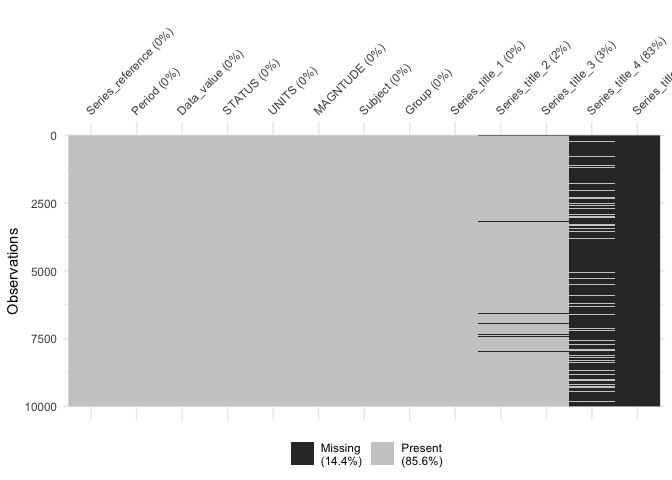

```r
# your code here
# install.packages("visdat")
library(visdat)
Overseas_ti %>%
  sample_n(10000) %>%
  vis_miss(large_data_size = 9e+07)
```

### Hard Time Reflection

You have (at least) three choices. Which one would you pick? Discuss and implement.

1. drop the columns completely
2. use them with NAs inside
3. change the parsing of the column

### Example 2

Some other time you need to specify the type of the column by your self! We see that with an example from `readr`.

We are going to use the csv “challenge.csv”, that is in this folder. First, open it with Jupyter Lab and give it a look. Then, we read it in R.

```r
challenge <- "../data/challenge.csv" %>%
  read_csv()
```

A lot of read. And a familiar error. Let’s give a look to the problems.

```r
challenge %>%
  problems() %>%
  head()
```

| row | col | expected | actual | file |
| --- | --- | --- | --- | --- |

```r
"../data/challenge.csv" %>%
  read_csv(n_max = 1000) # we read only the first 1000
```

| x | y |
| --- | --- |
| 404 | NA |
| 4172 | NA |
| 3004 | NA |
| 787 | NA |
| 37 | NA |
| 2332 | NA |
| 2489 | NA |
| 1449 | NA |
| 3665 | NA |
| 3863 | NA |

[output cut: 990 more lines]

Similarly, we can skip the first 1000 rows and read from the rest:

```r
# now we have to specify the name of the columns as we have skip over the title
# row
"../data/challenge.csv" %>%
  read_csv(
    skip = 1001, # we skip the first 1000
    col_names = c("x", "y")
  )
```

| x | y |
| --- | --- |
| 0.238379751 | 16/01/2015 |
| 0.411679972 | 18/05/2018 |
| 0.746071676 | 5/09/2015 |
| 0.723450554 | 28/11/2012 |
| 0.614524137 | 13/01/2020 |
| 0.473980569 | 17/04/2016 |
| 0.578461039 | 14/05/2011 |
| 0.241593723 | 18/07/2020 |
| 0.114378662 | 30/04/2011 |
| 0.298344633 | 11/05/2010 |

[output cut: 990 more lines]

The first entries of the variable `x` before row 1001 seem to be integer. But then (see the `actual` column in challenge’s problems) it changes. In fact, `read_csv()` reads the first 1000 rows and then guess the type of the columns. In this case, the type changes after that.

We can solve this in two ways: by specifying the type of the columns or by asking `read_csv()` to read more rows before guessing.

We start with the latter. Go back an read the message that you got from `read_csv`, in particular the “Parsed with column specification” bit. That’s the attempt done by `read_csv()`:

```
cols(
  x = col_integer(),
  y = col_character()
)
```

You can copy and tweak it: change integer to double.

```r
challenge <- "../data/challenge.csv" %>%
  read_csv(col_types = cols(
    x = col_double(), # change this to col_double
    y = col_character()
  ))
```

No red messages, yet we are not satisfied. Consider now the variable `y`. In the slice of challenge we saw before, it looks like `y` is actually a date. Read `challenge.csv` again, this time specifying that `y` is a date.

```r
challenge <- "../data/challenge.csv" %>%
  read_csv(col_types = cols(
    x = col_double(), # change this to col_double
    y = col_character()
  ))
```

The other way is to ask read_csv to read more lines. You can do this by changing the `guess_max` argument:

```r
challenge <- "../data/challenge.csv" %>%
  read_csv(guess_max = 1001)
```

What are we looking at? I have no idea :-) Let’s plot it.

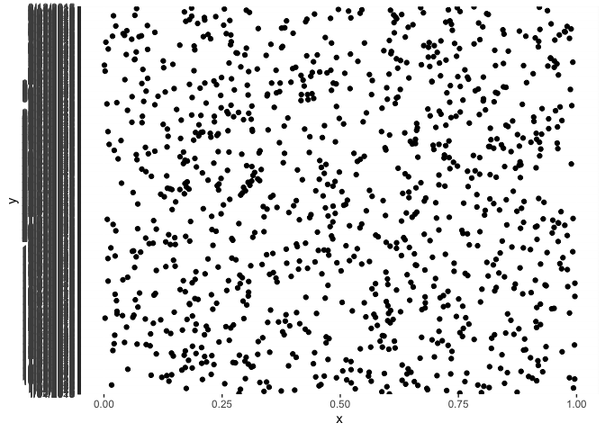

```r
challenge %>%
  drop_na() %>%
  ggplot(aes(x = x, y = y)) +
  geom_point()
```

Not good. Change the data type manually:

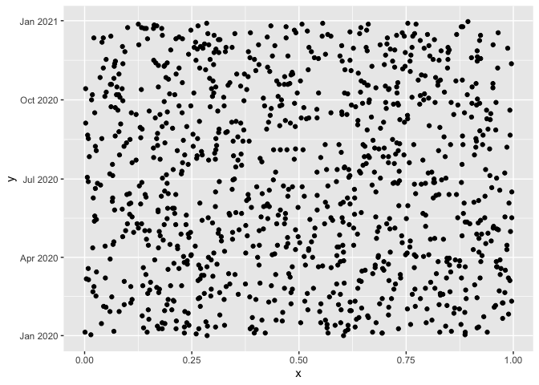

```r
challenge %>%
  drop_na() %>%
  mutate(y = as.Date(y, "%d/%m/%y")) %>%
  ggplot(aes(x = x, y = y)) +
  geom_point()
```

## Your turn

Try to read some other csv file from the stats nz website we used before. Do you find any error? Can you solve it?

```r
employment_url <- "https://www.stats.govt.nz/assets/Uploads/Employment-indicators/Employment-indicators-June-2021/Download-data/employment-indicators-june-2021-csv-tables.zip"
destfile <- "test.zip"
curl::curl_download(employment_url, destfile)
employment <- read_csv(unzip(destfile), n_max = 10)
spec(employment)
```

## Out of R

You can read csvs, but you can also write them! The function is `write_csv()`.

```r
library(singer)

# singer_locations %>%
#   write_csv("singer_locations.csv")
# singer_from_file <- read_csv("singer_locations.csv")
# all_equal(singer_locations, singer_from_file)
```

All as expected. Let’s try to break things ;-)

## CSV and its cousins

We mentioned at the beginning that comma separeted value files are part of a large community. `readr` has other functions (which behave very similarly) for the other members of the family: discover them by typing `read_` and then hitting the *tab* key.

Use the syntax `?function` (where *function* is the function you care about) to see what this other `read_...` functions are for.

## Advanced: excel

Excel files are not strictly separated files. If you are lucky they are, almost, an XML file: we will speak about them in the web as data labs and lectures. If you are not lucky, they are a mess.

Whether you are lucky or not depends on how the person who decided to write the excel file. If they decided to simply use it as a table, with one table per sheet, no fancy fonts, colors, or other embellishments, then you might be lucky. Otherwise, you are not.

In both cases, R has a variety of libraries to help you read and write excel files.

### lucky

The first one we see is [**readxl**](https://readxl.tidyverse.org/). It is installed when you install tidyverse, but it is not loaded by default. So you need to load it (in the usual way). We are straight reading from challenge.xslx (the same example as before, so do expect the same error. But more.

```r
library(readxl) # From Jenny Brian et al.

# # Expect a lot of red!
# "../data/challenge.xlsx" %>%
#   read_excel() %>%
#   glimpse()
```

WOW, that’s a lot of error. Luckily, we know already how to solve. Don’t we? It’s again that error in guessing the type of columns.

[output not shown]

```r
"../data/challenge.xlsx" %>%
  read_excel(guess_max = 1001) %>%
  glimpse()
```

```
## Rows: 2,000
## Columns: 2
## $ x <dbl> 404, 4172, 3004, 787, 37, 2332, 2489, 1449, 3665, 3863, 4374, 875, 1…
## $ y <dttm> NA, NA, NA, NA, NA, NA, NA, NA, NA, NA, NA, NA, NA, NA, NA, NA, NA,…
```

Much better.

`readxl` works well when the data is tabular, i.e. it resemble closely a csv file and you hit lucky.

### unlucky

If the original excel file is a glorious mess of colors, fonts, more than on table per sheet, and so on you may still be able to recover the information using tidyxl. This one does not come with the tidyverse, and you need to install it.

You might need to restart your R kernel here, if Rcpp need to be upgraded.

```r
install.packages("tidyxl")
```

Open the file “titanic.xlsx” with excel (or numbers or any other spreadsheet program) and look at its structure. Then open it with `tidyxl`. Instead of producing a table, every non-empty cell in the excel file is recorded with its address (row number and column letter in excel), the content, the colour, and all its information. Then it is up to you to use that information wisely :-) This is one of the most advanced areas of wrangling, it is so because spreadsheet offer a lot of freedom to users, and users use all that freedom to write data in very creative ways. Your task is often that of taming that creativity and producing a rigidly structured dataframe. It is hard job.

A good [resource](https://nacnudus.github.io/spreadsheet-munging-strategies/) is this online free book by the developers of `tidyxl` (and `unpivotr`):

```r
library(tidyxl)
titanic <- xlsx_cells("../data/titanic.xlsx")
titanic %>% glimpse()
```

```
## Rows: 60
## Columns: 24
## $ sheet               <chr> "Sheet1", "Sheet1", "Sheet1", "Sheet1", "Sheet1", …
## $ address             <chr> "C1", "D1", "E1", "F1", "G1", "C2", "D2", "E2", "F…
## $ row                 <int> 1, 1, 1, 1, 1, 2, 2, 2, 2, 2, 3, 3, 4, 4, 4, 4, 4,…
## $ col                 <int> 3, 4, 5, 6, 7, 3, 4, 5, 6, 7, 1, 2, 1, 2, 4, 5, 6,…
## $ is_blank            <lgl> FALSE, FALSE, TRUE, FALSE, TRUE, FALSE, FALSE, FAL…
## $ content             <chr> "0", "1", NA, "2", NA, "3", "4", "5", "4", "5", "6…
## $ data_type           <chr> "character", "character", "blank", "character", "b…
## $ error               <chr> NA, NA, NA, NA, NA, NA, NA, NA, NA, NA, NA, NA, NA…
## $ logical             <lgl> NA, NA, NA, NA, NA, NA, NA, NA, NA, NA, NA, NA, NA…
## $ numeric             <dbl> NA, NA, NA, NA, NA, NA, NA, NA, NA, NA, NA, NA, NA…
## $ date                <dttm> NA, NA, NA, NA, NA, NA, NA, NA, NA, NA, NA, NA, N…
## $ character           <chr> "Age", "Child", NA, "Adult", NA, "Survived", "No",…
## $ character_formatted <list> [<tbl_df[1 x 14]>], [<tbl_df[1 x 14]>], <NULL>, […
## $ formula             <chr> NA, NA, NA, NA, NA, NA, NA, NA, NA, NA, NA, NA, NA…
## $ is_array            <lgl> FALSE, FALSE, FALSE, FALSE, FALSE, FALSE, FALSE, F…
## $ formula_ref         <chr> NA, NA, NA, NA, NA, NA, NA, NA, NA, NA, NA, NA, NA…
## $ formula_group       <int> NA, NA, NA, NA, NA, NA, NA, NA, NA, NA, NA, NA, NA…
## $ comment             <chr> NA, NA, NA, NA, NA, NA, NA, NA, NA, NA, NA, NA, NA…
## $ height              <dbl> 14.4, 14.4, 14.4, 14.4, 14.4, 14.4, 14.4, 14.4, 14…
## $ width               <dbl> 8.38, 8.38, 8.38, 8.38, 8.38, 8.38, 8.38, 8.38, 8.…
## $ row_outline_level   <dbl> 1, 1, 1, 1, 1, 1, 1, 1, 1, 1, 1, 1, 1, 1, 1, 1, 1,…
## $ col_outline_level   <dbl> 1, 1, 1, 1, 1, 1, 1, 1, 1, 1, 1, 1, 1, 1, 1, 1, 1,…
## $ style_format        <chr> "Normal", "Normal", "Normal", "Normal", "Normal", …
## $ local_format_id     <int> 2, 3, 3, 3, 3, 2, 3, 3, 3, 3, 2, 2, 3, 3, 1, 1, 1,…
```

If we want to look at the 1st row and ist content, we can operate on `titanic` (which is dataframe).

```r
titanic %>%
  slice(1) %>%
  glimpse()
```

```
## Rows: 1
## Columns: 24
## $ sheet               <chr> "Sheet1"
## $ address             <chr> "C1"
## $ row                 <int> 1
## $ col                 <int> 3
## $ is_blank            <lgl> FALSE
## $ content             <chr> "0"
## $ data_type           <chr> "character"
## $ error               <chr> NA
## $ logical             <lgl> NA
## $ numeric             <dbl> NA
## $ date                <dttm> NA
## $ character           <chr> "Age"
## $ character_formatted <list> [<tbl_df[1 x 14]>]
## $ formula             <chr> NA
## $ is_array            <lgl> FALSE
## $ formula_ref         <chr> NA
## $ formula_group       <int> NA
## $ comment             <chr> NA
## $ height              <dbl> 14.4
## $ width               <dbl> 8.38
## $ row_outline_level   <dbl> 1
## $ col_outline_level   <dbl> 1
## $ style_format        <chr> "Normal"
## $ local_format_id     <int> 2
```

```r
titanic %>%
  slice(1) %>%
  select(address, row, col, character)
```

| address | row | col | character |
| --- | --- | --- | --- |
| C1 | 1 | 3 | Age |

### Your turn

Try with another row and see what it contains.

If you want to become a excel-to-R ninja (which is quite a good idea, given the amount of valuable data sleeping in companies’ excel files) read more. Similar project you may want to look into are [unpivotr](https://nacnudus.github.io/unpivotr/) and [jailbreaker](https://github.com/rsheets/jailbreakr).

## Write excel

If you ever want to write to an excel (maybe because your colleague do work just using excel and you are trying to bring smoothly them to R), writexl is what you are looking for.

```r
install.packages("writexl")
```

The behaviour of its main function `write_xlsx()` is similar to `write_csv()`.

```r
library(writexl)
challenge %>% write_xlsx(path = "challenge.xlsx")
read_excel("challenge.xlsx", guess_max = 1001) %>%
  glimpse()
```